# PHP2510 Assignment #1 Answer Key

Peter Lipman

2025-10-05

## Set Up

```r
setwd("/Users/peterjlipman/Desktop/brown/PHP2510 Principles Fall25")
data <- read.csv("births14.csv")
library(tidyverse)
set.seed(12345)
```

## Question 1

Determine whether you would model each variable below using a discrete or continuous random variable. What distribution would be most reasonable? Justify your choice.

- premie
- visits
- mage

```r
summary(data)
```

```
##       fage            mage          mature              weeks
##  Min.   :15.00   Min.   :14.00   Length:1000        Min.   :21.00
##  1st Qu.:26.00   1st Qu.:24.00   Class :character   1st Qu.:38.00
##  Median :31.00   Median :28.00   Mode  :character   Median :39.00
##  Mean   :31.13   Mean   :28.45                      Mean   :38.67
##  3rd Qu.:35.00   3rd Qu.:33.00                      3rd Qu.:40.00
##  Max.   :85.00   Max.   :47.00                      Max.   :46.00
##  NA's   :114
##     premie              visits          gained          weight
##  Length:1000        Min.   : 0.00   Min.   : 0.00   Min.   : 0.750
##  Class :character   1st Qu.: 9.00   1st Qu.:20.00   1st Qu.: 6.545
##  Mode  :character   Median :12.00   Median :30.00   Median : 7.310
##                     Mean   :11.35   Mean   :30.43   Mean   : 7.198
##                     3rd Qu.:14.00   3rd Qu.:38.00   3rd Qu.: 8.000
##                     Max.   :30.00   Max.   :98.00   Max.   :10.620
##                     NA's   :56      NA's   :42
##  lowbirthweight         sex               habit             marital
##  Length:1000        Length:1000        Length:1000        Length:1000
##  Class :character   Class :character   Class :character   Class :character
##  Mode  :character   Mode  :character   Mode  :character   Mode  :character
##
##
##
##
##    whitemom
##  Length:1000
##  Class :character
##  Mode  :character
##
##
##
##
```

```r
table(data$premie)
```

```
##
## full term    premie
##       876       124
```

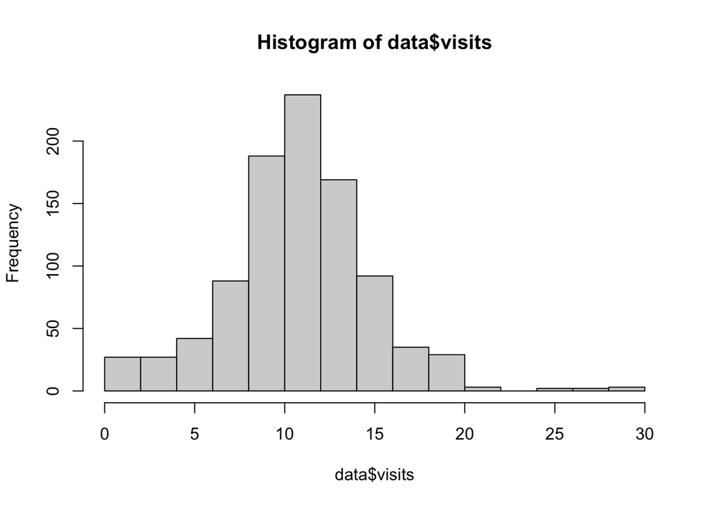

```r
hist(data$visits)
```

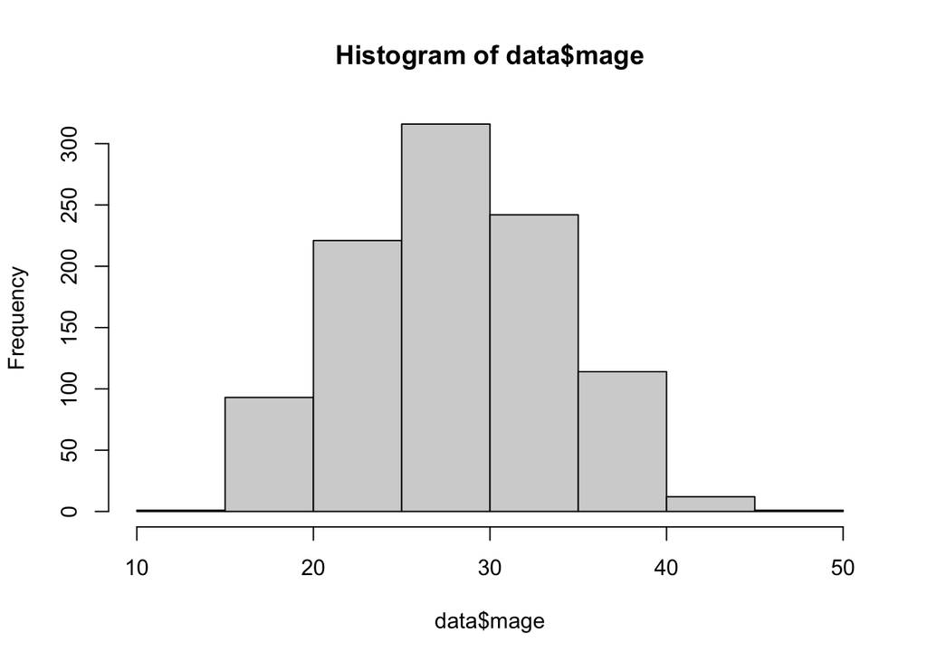

```r
hist(data$mage)
```

- premie is a binary variable, so the bernoulli distribution is appropriate (being one value of “premie” is like a flip of a biased coin)
- visits is a count variable, so a poisson distribution is the most reasonable choice. it has a clear central tendancy, although is over-dispersed in the tails.
- while age is typically continuous, mage is a discrete count variable because it has been rounded to years; so a poisson distribution would be a reasonable choice. full credit will also be given to choosing normal, since it has a clear central tendancy and could be viewed as a continuous random variable with measurement error/noise (so long as it is explained in that manner).

## Question 2

Calculate the mean and the standard deviation of the “gained” variable. Compare the actual distribution of “gained” against a reasonably-parametrized normal distribution. How similar or different are they?

```r
mean(data$gained, na.rm=T)
```

```
## [1] 30.42589
```

```r
sd(data$gained, na.rm=T)
```

```
## [1] 15.24253
```

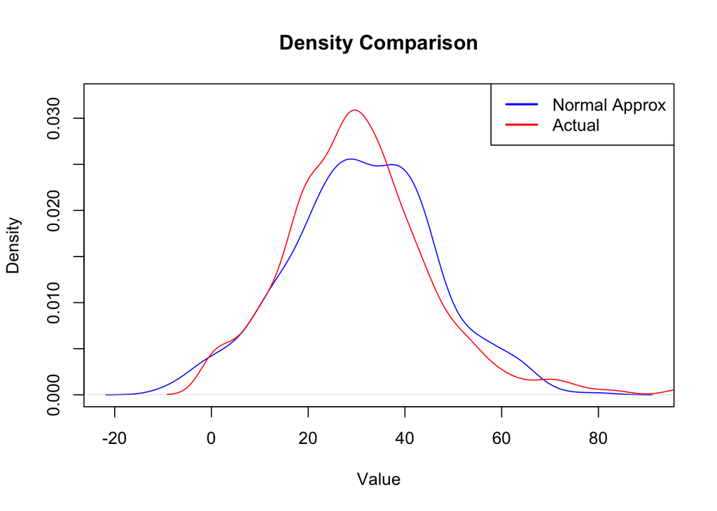

```r
x <- rnorm(1000, mean(data$gained, na.rm=T), sd(data$gained, na.rm=T))
d.x <- density(x)
d.g <- density(data$gained, na.rm=T)
max_y <- max(d.x$y, d.g$y)

plot(density(x), col = "blue", ylim = c(0, 1.05 * max_y), xlab = "Value", main = "Density Comparison")
lines(density(data$gained, na.rm=T), col = "red")
legend("topright",
       legend = c("Normal Approx", "Actual"),
       col = c("blue", "red"),
       lwd = 2)
```

The distributions are roughly similar, although the actual values of “gained” are more peaked at the center. The normal distribution does not correctly model that gaining < 0 is not compatible with the data.

## Question 3

Derive the variance of a bernoulli(p) random variable by hand. Calculate the variance of the “sex” variable (coded to 1/0 for male/female) using your result and using R’s ‘var’ function. Explain your findings.

```r
table(data$sex)
```

```
##
## female   male
##    495    505
```

```r
mu <- mean(as.numeric(data$sex == "male"))
sigma2 <- var(as.numeric(data$sex == "male"))
n <- nrow(data)
mu
```

```
## [1] 0.505
```

```r
sigma2
```

```
## [1] 0.2502252
```

```r
mu*(1-mu)
```

```
## [1] 0.249975
```

```r
sigma2*(n-1)/n
```

```
## [1] 0.249975
```

A bernoulli(p) RV is defined as equaling 1 with prob p, 0 o/w. It has expected value of 1 * p + 0 * (1-p) = p. Using the formula for E[g(X)] with g(X) = (X-p)^2, it has variance of (1-p)^2 * p + (0-p)^2 * (1-p) = p(1-p)^2 + (1-p)p^2 = p(1-p)(1-p+p) = p(1-p). Note that you can also show this result by taking E[X^2] - E[X]^2. In this dataset, there are 505 males and 495 females, so p = .505. The variance would then equal 0.505 * 0.495 = 0.249975 (if we assume this p is the true value of the underlying probability of the random variable). This is not the exact result in R (but it is close!) because R uses a denominator of n-1, assuming p is unknown and being estimate from a sample.

## Question 4

What percent of babies were born more than 2 standard deviations away from the mean in terms of weeks? Write this in probabilistic notation and then calculate it in R.

```r
mu <- mean(data$weeks)
s <- sd(data$weeks)
mean(abs(data$weeks - mu) > 2*s)
```

```
## [1] 0.051
```

Let X be a RV that follows some distribution f with mean mu and standard deviation s. This models the length of the pregnancy in weeks. Note that we do not actually need to assume this follows any particular distribution (i.e. Normal). We wish to calculate: P(|X - mu| > 2s)

The answer in this dataset is .051

## Question 5

Generate code, using the tidyverse library and pipes, that converts the full dataset to a subset that only contains premature female babies with fathers under 40.

```r
# Use a series of filters to create the subset
d2 <- data %>%
  filter(premie == "premie" & sex == "female" & fage < 40)

head(d2)
```

```
##   fage mage      mature weeks premie visits gained weight lowbirthweight    sex
## 1   32   31 younger mom    36 premie     12     48   6.75        not low female
## 2   37   36  mature mom    36 premie     10     20   6.13        not low female
## 3   27   25 younger mom    34 premie      7     20   4.32            low female
## 4   36   32 younger mom    33 premie      6     40   5.56        not low female
## 5   34   34 younger mom    36 premie     10     14   4.31            low female
## 6   37   38  mature mom    36 premie     10     32   6.04        not low female
##       habit     marital  whitemom
## 1 nonsmoker     married     white
## 2 nonsmoker     married     white
## 3    smoker     married     white
## 4 nonsmoker not married     white
## 5 nonsmoker     married     white
## 6 nonsmoker     married not white
```

```r
nrow(d2)
```

```
## [1] 40
```

The code above filters to just the 40 observations that meet the criteria

## Question 6

Let’s say I randomly select n observations (with replacement) from this dataset and calculate the oldest mother’s age. Use simulations to determine the smallest value of n such that I find the true maximum over 50% of the time.

```r
results <- c()
for (n in 1:1000){
  sampled.max <- c()
  for (i in 1:10000){
    sampled.max[i] <- max(sample(data$mage, n, replace = T))
  }
  results[n] <- mean(sampled.max == max(data$mage))
}
which(results > 0.5)[1]
```

```
## [1] 688
```

We need to sample 688 observations (or more) to have a greater than 50% chance of observing the true maximum value. Note that if we didn’t do simulations, we could actually calculate this directly: with each sample, we have a 999/1000 chance of “missing” the max, and we are solving for which n makes (999/1000)^n < 50% (it’s 693, so our simulation isn’t perfect)

## Question 7

A colleague suggests that the number of doctor visits is predictive of whether the baby will be born premature. They hypothesize that if there are 10 or more visits, there is less of a chance of the baby being premature.

- Does the data support that statement?
- What is the sensitivity and specificity of this criteria?
- What do you say to your colleague about their hypothesis and its strength/usefulness?

```r
mean(data$premie == "premie", na.rm=T)
```

```
## [1] 0.124
```

```r
mean(data$premie[data$visits < 10] == "premie", na.rm=T)
```

```
## [1] 0.2333333
```

```r
t <- table(data$visits < 10, data$premie)
t
```

```
##
##         full term premie
##   FALSE       645     59
##   TRUE        184     56
```

```r
t[2,2]/(t[2,2] + t[1,2]) #sensitivity
```

```
## [1] 0.4869565
```

```r
t[1,1]/(t[1,1] + t[2,1]) #specificity
```

```
## [1] 0.7780458
```

- Yes, the data supports the claim, as the likelihood of being premie is 12.4% in the entire dataset, while 23.3% among those with 9 or fewer visits.
- Sensitivity (given premie status, likelihood of fewer than 10 visits) = 0.49
- Specificity (given full term status, likelihood of 10+) = 0.78
- This is a weak signal: when a baby is actually going to be a premie, the test (9 or fewer visits) will only predict that correctly 49% of the time. And when a baby is actually going to be full term, the test will only predict that correctly 78% of the time. Note: if you decided to define your test in the opposite way (10+ visits is “positive”) or disease in the opposite way (being full term is “positive”), that will still be accepted for full credit so long as your resulting metrics and interpretation are correct. It is important to see that there is a sensitivity/specificity trade-off (as one goes up, the other goes down) when you turn a continuous variable into a binary one (i.e. via a cut-off value). Different cut-offs may be chosen for different sensitivity/specificity desires.

## Question 8

Why do we model real-world data using a theoretical distribution? What does this act of modeling accomplish, and what are the limitations of fitting a tidy, mathematical model to messy, human data? Contextualize your answer by drawing on an example from the birth dataset.

```r
#code intentionally left blank (n/a)
```

Theoretical distributions have well-understood properties (e.g. means, variances) and allow us to make probabilistic statements. While claiming a certain variable follows a certain distribution may be an oversimplification or rely on hard-to-prove assumptions, it also allows us to make predictions, quantify uncertainty, and summarize the population as a whole. For example, Q2 shows us that the weight gained by the mother is well-approximated by a N(30, 15^2), so we can summarize the entire population by just reporting 2 parameters.

## Question 9

In your own words, what is the core purpose of using simulation in this homework? When would you choose to simulate a process rather than just calculating a single, definitive answer, and what unique insights does that approach provide? Contextualize your answer by drawing on an example from the birth dataset.

```r
#code intentionally left blank (n/a)
```

Simulations are especially useful for calculating complex probabilistic statements that are difficult to determine theoretically, or for which no closed-form solution may exist. They are also useful for quantifying uncertainty in a dataset without assuming that a variable follows a particular theoretical distribution (instead, relying on the observed distribution in the dataset). While Q6 can actually be solved theoretically (see the note), our simulation results can be clearer and draw an informative picture without complex probability statements. While simulations result in approximations, we have enough computational power that the answer is accurate enough for most use cases.